# **ESTADÍSTICA PARA EL ANÁLISIS POLÍTICO 2**

## **Clase 02**

El análisis exploratotio de datos **no supone nada**.

ESCALAS

- Categóricas: Nominales (Dicotómicas y Politómicas) y Ordinales
- Numéricas: Intervalo (Discretas y Continuas) y De Razón (Discretas y Continuas)

**¿Quién no sabe la diferencia entre variables de intervalo y de razón?** Además, el SPSS solo pone *Escala*.

Como ningún software le presta atención, la mala noticia es que depende de uno que se dé cuenta.

¿Cuál sería la diferencia?

- Escala de razón: el cero va a ser cero en cualquiera de las unidades de medida.

Ustedes tienen una tabla de frecuencias, los estadísticos y los gráficos.

Los estadísticos se clasifican en:

- Centralidad [representatividad, valor típico]
- Dispersión []
- Forma [simetría y curtosis]

### **VARIABLE NOMINAL**

¿Tabla de frecuencias? Sí

¿Estadísticos?

De centralidad: **moda**

De dispersión: uno puede usar la información de la tabla de frecuencia para construir un **índice de Gini**.

- Más cercano al 1: harta desigualdad.
- Más cercano al 0: mayor igualdad.

**Número efectivo de partidos** (NEP): manera de registrar la unimodalidad o multimodalidad

- Revisar INFOGOB

De forma: simetría y curtosis

¿Qué gráficos?

- Gráfico de barras
- Torta

**La comunidad de visualización ha objetado, objeta y va a seguir objetando las tortas.**

### **VARIABLE ORDINAL**

¿Tabla de frecuencias? Sí

¿Estadísticos?

De centralidad: **moda** y **mediana**

De dispersión: **RIC** (rango intercuartil)

De simetría: cuartiles o **cuantiles**

¿Gráficos?

- Gráfico de barras
- Torta [**pero ya está vetada**]
- Boxplot: me dice la mediana y los *outliers*.

### **VARIABLE DISCRETO**

¿Tabla de frecuencias? Sí. **PERO OJO**: solo si hay poco rango. Si aumenta, necesito construir **intervalos**

¿Estadísticos?

De centralidad: **moda**, **mediana** y **media**

De dispersión: **RIC**, **varianza / desviación estándar**

De simetría: Skew

- CERO: Simétrica
- Positiva: cola hacia la derecha
- Negativa: cola hacia la izquierda

¿Gráficos?

- Gráfico de barras

### **VARIABLE CONTINUA**

¿Tabla de frecuencias? Mmm… **solo para intervalos**

¿Gráficos?

- Histograma [por eso junto las barras]

**BIVARIADA**

cat - Cat

- Tabla de contingencia

Cat - Num

- Prueba t
- ANOVA

Num - Num

- Pearson

[**El Pearson no mide la correlación; mide la correlación lineal.**]

# **SOBRE EL TRABAJO GRUPAL**

Inteligencia. Insight. Organizarle data que él no tenía.

Data, que la tenga él, o que él sepa dónde están.

¿Podría ser un *perfil del militante morado*?

Al día de hoy:

- SERVIR
- CEPLAN
- País (MIDIS)
- BB DD Pueblos Indígenas y Amazónicos (MINCUL)
- MININTER
- MINEDU [Mil cosas]
- Candidato a la alcaldía de Miraflores [Luis Molina, PSN]
- Ocrospoma [Lima]
- Saldaña [Lima]

## *EXPLORACIÓN DE VARIABLES DICOTÓMICAS*

Carguemos la data:

```r
library(RCurl)
link='https://docs.google.com/spreadsheets/d/1bDMM5s3PDC5awrSkILFRPJMlQ0j95TtVxErvvNNOHPU/pub?gid=914658997&single=true&output=csv'
myCsv <- getURL(link)
namesOfCols=c('timeStamp','nombre','apellido','tipoCole','distritoNace','regionNace','edad','sexo', 'religion')
# parsing as csv
myData=read.csv(textConnection(myCsv),col.names=namesOfCols)
```

Aquí vemos cómo se comporta una dicotómica:

```r
table(myData$sexo)
```

```
##
##  Femenino Masculino
##        24         9
```

De manera gráfica:

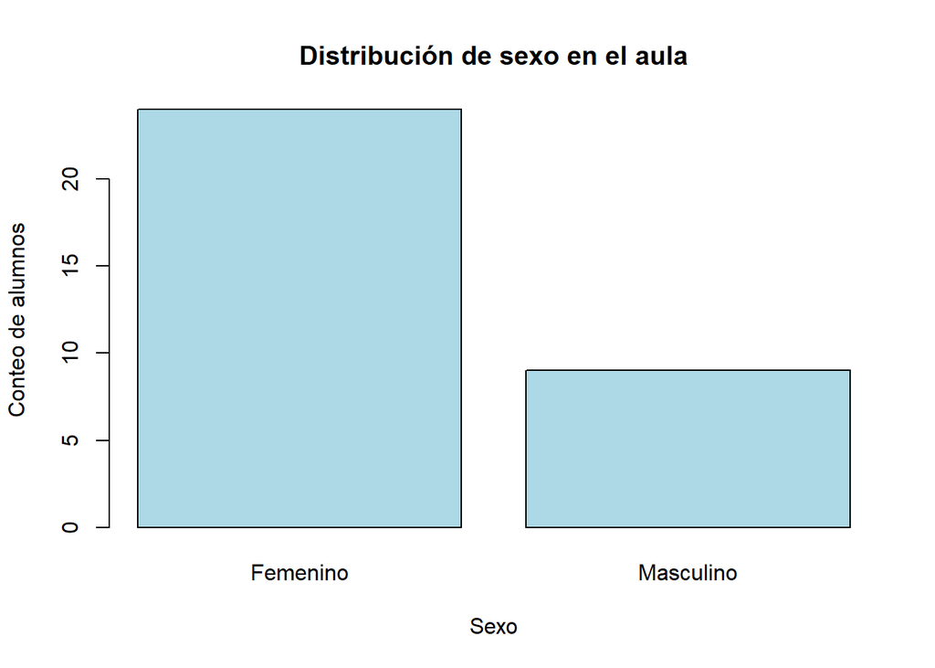

```r
toPlot=table(myData$sexo)
barplot(toPlot,col='lightblue',
        xlab='Sexo',
        ylab='Conteo de alumnos',
        main='Distribución de sexo en el aula')
```

Para verlo como porcentajes tenemos:

```r
prop.table(table(myData$sexo)) # como plotearias estos resultados?
```

```
##
##  Femenino Masculino
## 0.7272727 0.2727273
```

Es útil saber si la diferencia es significativa usando la prueba chi-cuadrado:

```r
distribution=table(myData$sexo)
chisq.test(distribution)
```

```
##
##  Chi-squared test for given probabilities
##
## data:  distribution
## X-squared = 6.8182, df = 1, p-value = 0.009023
```

Un valor significativo del p-value (menor a 0.05) sugiere que hay diferencias (se rechaza que haya comportamiento uniforme).

En esta situación, podemos considerar que la moda es relevante:

```r
names(distribution[which.max(distribution)]) #asi se obtiene
```

```
## [1] "Femenino"
```

## **EXPLORACIÓN DE VARIABLES CATEGÓRICAS NO ORDINALES**

Exploremos la región de procedencia:

```r
table(myData$regionNace)
```

```
##
## Ãncash  Callao   Cusco     Ica  JunÃn    Lima   Lima    Tacna  Tumbes
##       1       1       1       1       1      25       1       1       1
```

¿Hay dos Limas?

```r
# asumo que alguien escribió "Lima " (con algun espacio en blanco)
# así que mejor leo eliminando (stripping) los espacios en cada celda...
myData=read.csv(textConnection(myCsv),col.names=namesOfCols,stringsAsFactors =FALSE,strip.white = TRUE)
# por que 'stringsAsFactors =FALSE'??
table(myData$regionNace)
```

```
##
## Ãncash  Callao   Cusco     Ica  JunÃn    Lima   Tacna  Tumbes
##       1       1       1       1       1      26       1       1
```

Símbolos raros por el lenguaje español!… veamos:

```r
names(table(myData$regionNace))
```

```
## [1] "Ãncash" "Callao"  "Cusco"   "Ica"     "JunÃn"  "Lima"    "Tacna"
## [8] "Tumbes"
```

Buscando la ubicación, cambiamos a lo que deseamos:

```r
# esto es un problema de 'encoding'
ancashBad=names(table(myData$regionNace))[1]
juninBad=names(table(myData$regionNace))[5]

myData$regionNace[myData$regionNace==ancashBad]='Ancash'
myData$regionNace[myData$regionNace==juninBad] ='Junin'
table(myData$regionNace)
```

```
##
## Ancash Callao  Cusco    Ica  Junin   Lima  Tacna Tumbes
##      1      1      1      1      1     26      1      1
```

Grafiquemos nuestra variable:

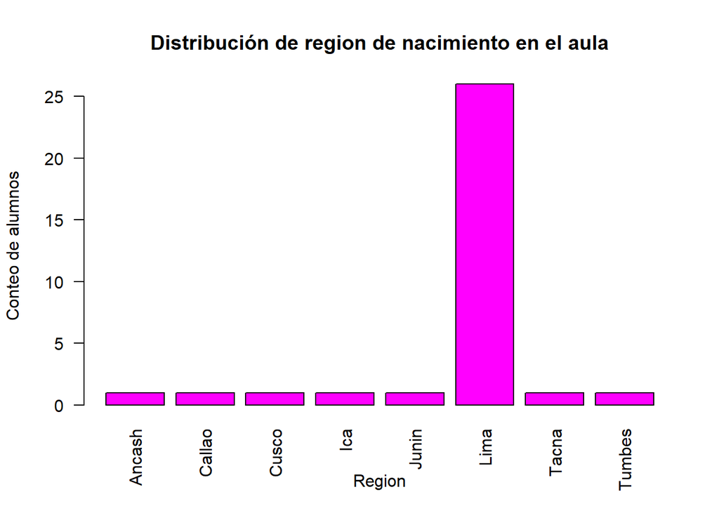

```r
toPlot=table(myData$regionNace)
barplot(toPlot,col='magenta',
        xlab='Region',
        ylab='Conteo de alumnos',
        main='Distribución de region de nacimiento en el aula',
        las=2)
```

Veamos la relevancia de la moda:

```r
distribution=table(myData$regionNace)
chisq.test(distribution)
```

```
##
##  Chi-squared test for given probabilities
##
## data:  distribution
## X-squared = 132.58, df = 7, p-value < 2.2e-16
```

```r
distribution=table(myData$regionNace)
chisq.test(distribution, simulate.p.value = T)
```

```
##
##  Chi-squared test for given probabilities with simulated p-value
##  (based on 2000 replicates)
##
## data:  distribution
## X-squared = 132.58, df = NA, p-value = 0.0004998
```

Lo anterior corrobora que hay una moda sobresaliente, la cual es:

```r
names(distribution[which.max(distribution)])
```

```
## [1] "Lima"
```

Pero si fuera el caso de religión:

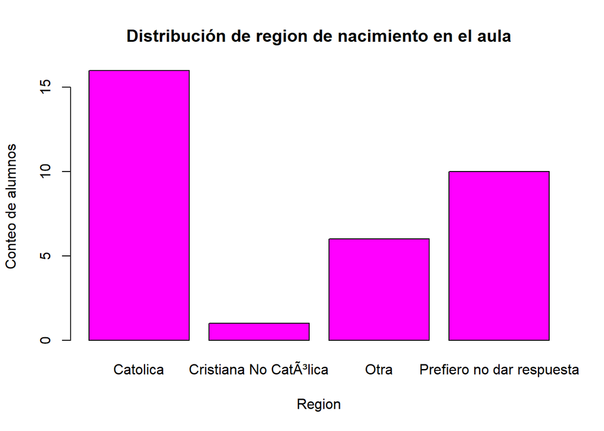

```r
toPlot=table(myData$religion)
barplot(toPlot,col='magenta',
        xlab='Region',
        ylab='Conteo de alumnos',
        main='Distribución de region de nacimiento en el aula')
```

Dada la distribución de los valores no modales, es posible que el peso de la moda sea menor:

```r
distribution=table(myData$religion)
chisq.test(distribution)
```

```
##
##  Chi-squared test for given probabilities
##
## data:  distribution
## X-squared = 14.636, df = 3, p-value = 0.002155
```

Otra manera de ver la representatividad o dispersión de la moda es mediante el uso del **Gini Index**.

```r
library(DescTools)  # instalar antes!
Gini(table(myData$religion),na.rm = TRUE)
```

```
## [1] 0.4949495
```

Se diferencia el Gini de región?

```r
# deberia salir alto, pues Lima es una moda muy pronunciada:
Gini(table(myData$regionNace),na.rm = TRUE)
```

```
## [1] 0.7575758
```

## **EXPLORACIÓN DE VARIABLES CATEGÓRICAS ORDINALES**

Abramos nuestro archivo del *American National Election Studies Survey* (ANES):

```r
library(haven)
varsOfInterest=c("libcpre_self","libcpo_self")
folder="data"
fileName="anes_timeseries_2012.sav"
fileToRead=file.path(folder,fileName)
dataSpss=read_sav(fileToRead)
dataSpssSub=as.data.frame(dataSpss)[varsOfInterest]
```

Grafiquemos:

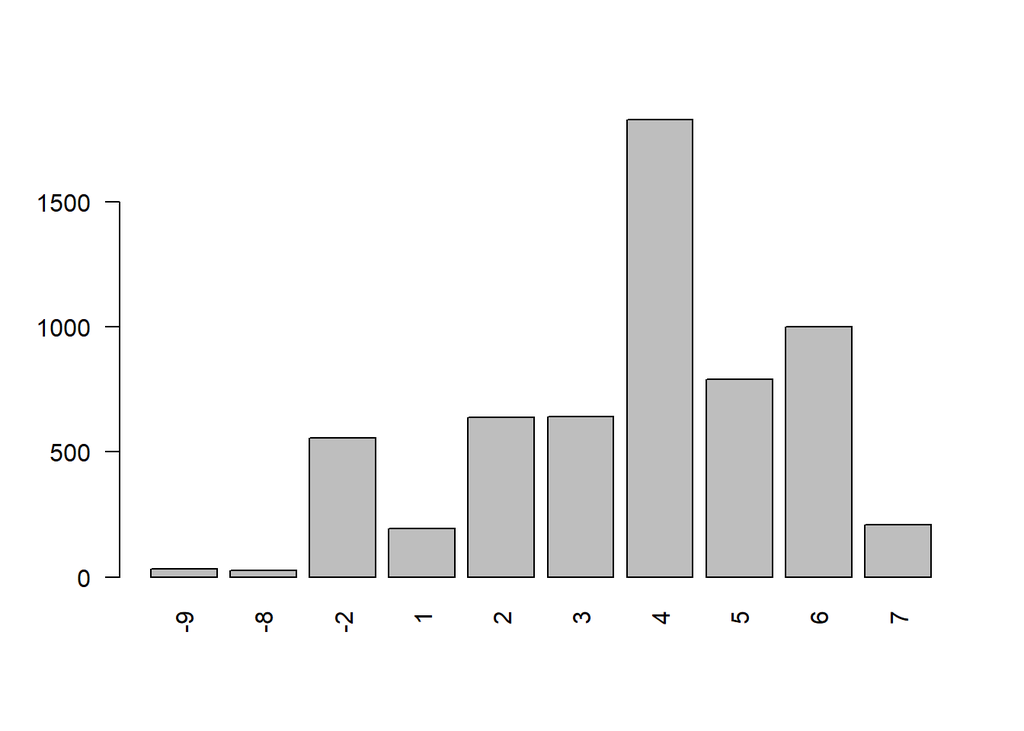

```r
barplot(table(dataSpssSub$libcpre_self),las=2)
```

Para saber qué representan los números:

```r
attr(dataSpssSub$libcpre_self,'labels')
```

```
##                         -9. Refused                      -8. Don't know
##                                  -9                                  -8
## -2. Haven't thought much about this                1. Extremely liberal
##                                  -2                                   1
##                          2. Liberal                 3. Slightly liberal
##                                   2                                   3
##     4. Moderate; middle of the road            5. Slightly conservative
##                                   4                                   5
##                     6. Conservative           7. Extremely conservative
##                                   6                                   7
```

Recodifiquemos los negativos como ‘perdidos’:

```r
var=dataSpssSub$libcpre_self
dataSpssSub$libcpre_self=ifelse(var<0,NA,var)
```

Actualicemos gráfica:

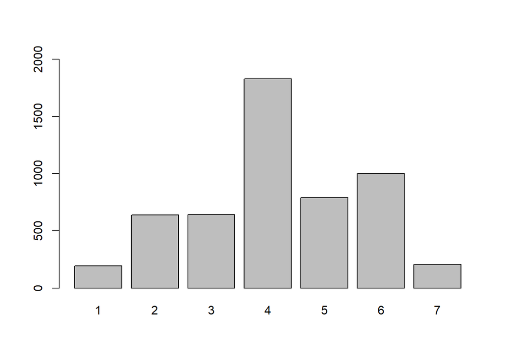

```r
theTable=table(dataSpssSub$libcpre_self)
barplot(theTable,ylim = c(0, 2000))
```

Falta transformar esta variable en ordinal:

```r
dataSpssSub$libcpre_self=ordered(dataSpssSub$libcpre_self)
head(dataSpssSub$libcpre_self)
```

```
## [1] 1    1    <NA> <NA> 2    <NA>
## Levels: 1 < 2 < 3 < 4 < 5 < 6 < 7
```

Lo mismo, con más detalle:

```r
# Formatting:
theLabels=c('XLiberal','Liberal','algo_liberal','moderado',
            'algo_conservador','Conservador','XConservador')
dataSpssSub$libcpre_self=factor(dataSpssSub$libcpre_self,
                                levels = c(1:7),
                                labels=theLabels,
                                ordered=T)
levels(dataSpssSub$libcpre_self)
```

```
## [1] "XLiberal"         "Liberal"          "algo_liberal"
## [4] "moderado"         "algo_conservador" "Conservador"
## [7] "XConservador"
```

Podemos calcular mediana en ordinales:

```r
Median(dataSpssSub$libcpre_self,na.rm = T)
```

```
## [1] moderado
## 7 Levels: XLiberal < Liberal < algo_liberal < ... < XConservador
```

Confirmemos:

```r
cumsum(prop.table(table(dataSpssSub$libcpre_self)))
```

```
##         XLiberal          Liberal     algo_liberal         moderado
##       0.03679245       0.15716981       0.27811321       0.62301887
## algo_conservador      Conservador     XConservador
##       0.77188679       0.96075472       1.00000000
```

La moda es:

```r
Mode(dataSpssSub$libcpre_self,na.rm = T)
```

```
## [1] "moderado"
```

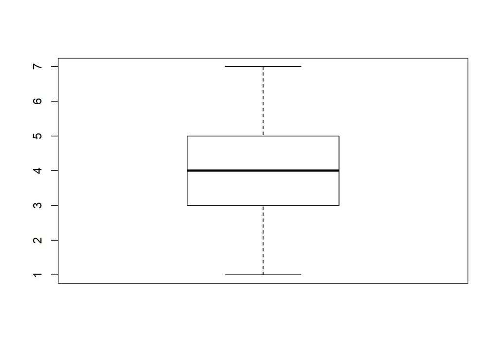

```r
boxplot(dataSpssSub$libcpre_self)
```

Comencemos a usar **ggplot2**, paquete preferido para los gráficos. Primero uno simple:

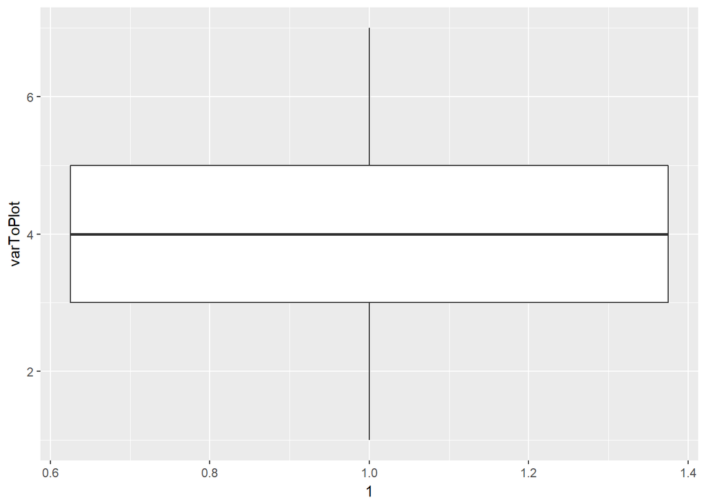

```r
library(ggplot2)
data=na.omit(dataSpssSub)
varToPlot=as.numeric(data$libcpre_self)
thePlot=ggplot(data, aes(x=1,y=varToPlot)) + geom_boxplot()
thePlot
```

Alteración:

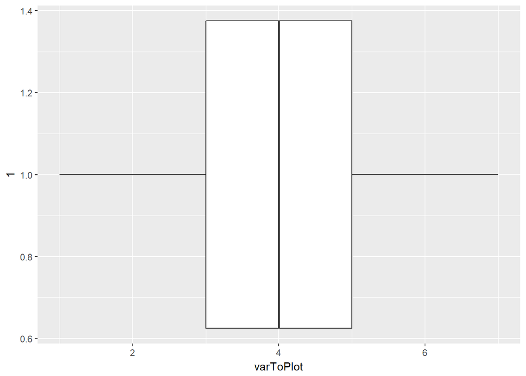

```r
thePlot = thePlot + coord_flip()
thePlot
```

Etiquetando eje:

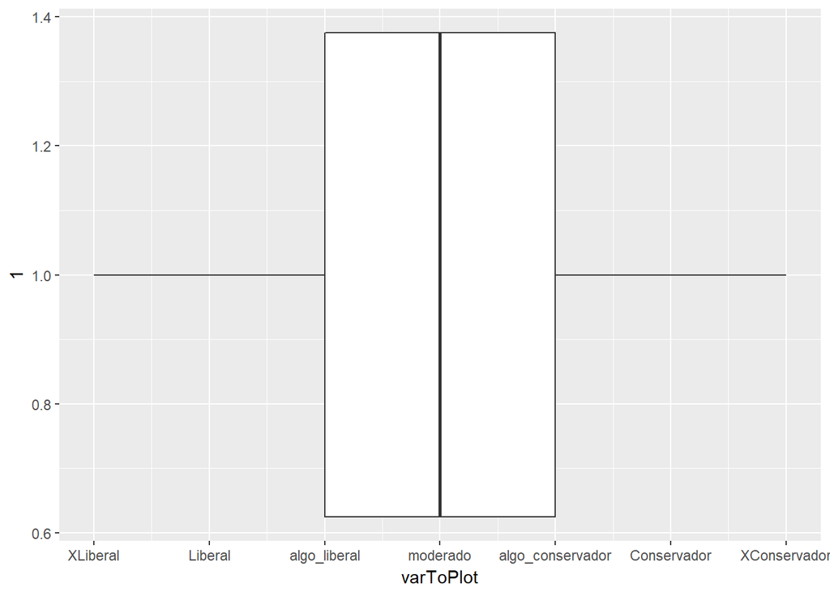

```r
thePlot= thePlot + scale_y_continuous(labels= theLabels,breaks=1:7)
thePlot
```

Otros elementos:

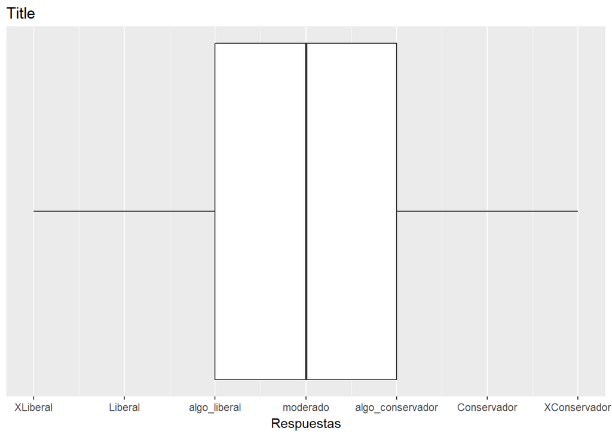

```r
thePlot + labs(title="Title", y = 'Respuestas', x=NULL) + scale_x_continuous(labels= NULL, breaks = NULL)
```

Finalmente, veamos la dispersión:

```r
Gini(table(dataSpssSub$libcpre_self),na.rm = T)
```

```
## [1] 0.4173585
```

## **EXPLORANDO CONTEOS**

La variable *edad* puede servir para ello:

```r
myData$edad
```

```
##  [1] "19"       "20"       "19"       "27"       "19"       "20"
##  [7] "20"       "20"       "19"       "20"       "20"       "21"
## [13] "25"       "20"       "23"       "19"       "20"       "20"
## [19] "19 aÃ±os" "24"       "20"       "19"       "19"       "21"
## [25] "18"       "19"       "24"       "19 aÃ±os" "23"       "21"
## [31] "19"       "25"       "16"
```

Pero alguien uso letras! Iré a cada celda y me quedo solo con los números:

```r
library(stringr)

# preparar 'regular expression'
regexp <- "[[:digit:]]+"

# procesando string
myData$edad=str_extract(myData$edad, regexp)
myData$edad=as.numeric(myData$edad)
myData$edad
```

```
##  [1] 19 20 19 27 19 20 20 20 19 20 20 21 25 20 23 19 20 20 19 24 20 19 19
## [24] 21 18 19 24 19 23 21 19 25 16
```

**OJO**: regexp es “*Regular Expression*”

Corresponde todavía el uso de barras:

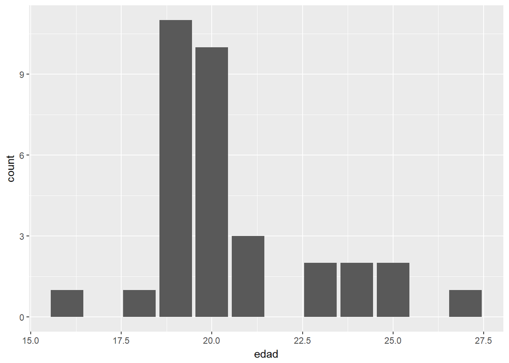

```r
ggplot(myData, aes(edad)) + geom_bar()
```

Veamos sus estadísticos:

```r
summary(myData$edad)
```

```
##    Min. 1st Qu.  Median    Mean 3rd Qu.    Max.
##   16.00   19.00   20.00   20.52   21.00   27.00
```

Un boxplot:

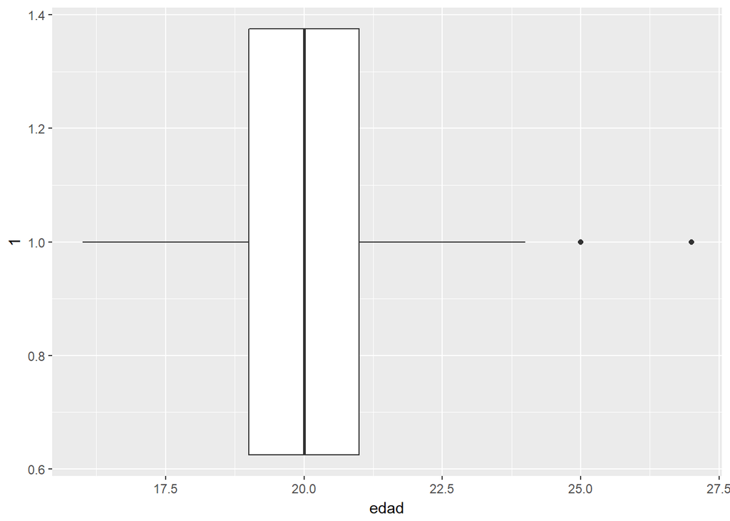

```r
ggplot(myData, aes(x = 1, y = edad)) + geom_boxplot() +coord_flip()
```

## **EXPLORANDO MEDICIONES**

Las mediciones dan valores continuos (aceptan decimales). Busquemos una data para analizarla:

```r
library(XML)
library(RCurl)
# URL
wiki="https://en.wikipedia.org/wiki/"
link = "List_of_countries_by_GDP_(PPP)_per_capita"

# Data
wikiLinkContents = getURL(paste0(wiki,link))
wikiTables = readHTMLTable(wikiLinkContents,
                           stringsAsFactors=FALSE)
```

```r
# how many?
length(wikiTables)
```

```
## [1] 8
```

Al visitar la web, nos damos cuenta la tabla de interés es la segunda:

```r
idx=wikiTables[[2]]
head(idx)
```

```
##   Rank Country/Territory    Int$
## 1    1             Qatar 127,660
## 2    2        Luxembourg 104,003
## 3    3         Singapore  90,151
## 4                 Macau  87,855
## 5    4            Brunei  76,884
## 6    5            Kuwait  71,887
```

```r
str(idx)
```

```
## 'data.frame':    192 obs. of  3 variables:
##  $ Rank             : chr  "1" "2" "3" "" ...
##  $ Country/Territory: chr  "Qatar" "Luxembourg" "Singapore" "Macau" ...
##  $ Int$             : chr  "127,660" "104,003" "90,151" "87,855" ...
```

**OJO**: chr es **character**.

Cambiemos de nombre y con:

```r
names(idx)=c('rank','country','gdp')
```

Tratemos de volver los *gdp* en número:

```r
as.numeric(idx$gdp)
```

```
##   [1]  NA  NA  NA  NA  NA  NA  NA  NA  NA  NA  NA  NA  NA  NA  NA  NA  NA
##  [18]  NA  NA  NA  NA  NA  NA  NA  NA  NA  NA  NA  NA  NA  NA  NA  NA  NA
##  [35]  NA  NA  NA  NA  NA  NA  NA  NA  NA  NA  NA  NA  NA  NA  NA  NA  NA
##  [52]  NA  NA  NA  NA  NA  NA  NA  NA  NA  NA  NA  NA  NA  NA  NA  NA  NA
##  [69]  NA  NA  NA  NA  NA  NA  NA  NA  NA  NA  NA  NA  NA  NA  NA  NA  NA
##  [86]  NA  NA  NA  NA  NA  NA  NA  NA  NA  NA  NA  NA  NA  NA  NA  NA  NA
## [103]  NA  NA  NA  NA  NA  NA  NA  NA  NA  NA  NA  NA  NA  NA  NA  NA  NA
## [120]  NA  NA  NA  NA  NA  NA  NA  NA  NA  NA  NA  NA  NA  NA  NA  NA  NA
## [137]  NA  NA  NA  NA  NA  NA  NA  NA  NA  NA  NA  NA  NA  NA  NA  NA  NA
## [154]  NA  NA  NA  NA  NA  NA  NA  NA  NA  NA  NA  NA  NA  NA  NA  NA  NA
## [171]  NA  NA  NA  NA  NA  NA  NA  NA  NA  NA  NA  NA  NA  NA  NA  NA  NA
## [188]  NA 855 814 773 652
```

**OJO**: La coma es un **caracter no numérico**.

Lo anterior falla pues los números tienen comas. Usemos el comando gsub para reemplazar *comas* por *nada*:

```r
idx$gdp=as.numeric(gsub(",", "", idx$gdp))
idx$gdp
```

```
##   [1] 127660 104003  90151  87855  76884  71887  69249  69231  67871  59561
##  [11]  59058  58322  57436  55158  51049  50704  49836  49136  48899  48111
##  [21]  48095  48005  47985  46698  46437  45047  42481  42314  42165  41275
##  [31]  39834  38639  38393  37740  37294  36833  36416  35179  34970  33232
##  [41]  32085  31870  31339  29972  29313  28933  27764  27602  27482  27267
##  [51]  26669  26490  25940  25710  25157  25145  24912  24555  24113  23024
##  [61]  22795  22348  21527  20422  20327  20047  19056  18938  18525  18077
##  [71]  18000  17944  17485  17439  17100  17042  16888  16643  16436  16318
##  [81]  16049  15553  15399  15319  15242  15026  14597  14493  14130  14116
##  [91]  13988  13761  13225  12903  12554  12278  12275  12262  11840  11783
## [101]  11720  11634  11539  11375  11290  11271  11109  10958  10235  10044
## [111]   9776   9396   9268   8976   8909   8678   8621   8330   8305   8227
## [121]   8220   7899   7873   7728   7218   6844   6676   6662   6616   6563
## [131]   6429   5942   5832   5710   5553   5452   5386   5328   5271   5106
## [141]   4447   4412   4328   4187   3891   3880   3737   3609   3601   3567
## [151]   3541   3521   3370   3361   3301   3249   3234   3080   3072   3008
## [161]   2631   2577   2479   2445   2375   2266   2119   2068   1977   1973
## [171]   1970   1946   1919   1823   1784   1782   1730   1672   1667   1657
## [181]   1550   1529   1505   1410   1265   1215   1134   1107    855    814
## [191]    773    652
```

Ahora sí pedimos un histograma:

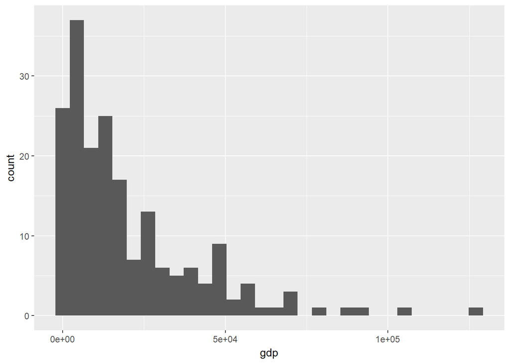

```r
ggplot(idx,aes(x=gdp)) + geom_histogram()
```

…Y nuestro boxplot:

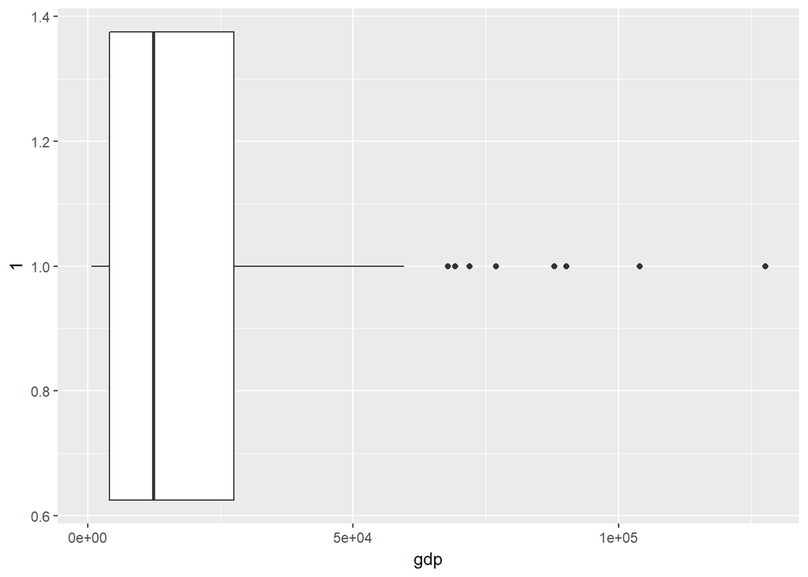

```r
ggplot(idx,aes(y=gdp,x=1)) + geom_boxplot() + coord_flip()
```

## **CATEGÓRICO - CATEGÓRICO**

Utilicemos los datos sobre contribuciones a candidatos y sus comités políticos del estado de Washington USA. Esta data procede de aquí: *Contributions to Candidates and Political Committees*.

```r
link='https://github.com/PoliticayGobiernoPUCP/EstadisticaPoliticaGobiernoII/blob/master/sesiones/data/governor.csv?raw=true'
governor=read.csv(link,stringsAsFactors = F)
```

Una mirada breve a lo que tenemos:

```r
str(governor)
```

```
## 'data.frame':    329866 obs. of  5 variables:
##  $ party                 : chr  "REPUBLICAN" "REPUBLICAN" "REPUBLICAN" "REPUBLICAN" ...
##  $ election_year         : int  2012 2012 2012 2012 2012 2012 2012 2012 2012 2012 ...
##  $ amount                : num  25 100 100 25 50 100 50 25 25 100 ...
##  $ contributor_occupation: chr  "" "" "RETIRED" "" ...
##  $ code                  : chr  "Individual" "Individual" "Individual" "Individual" ...
```

Veamos cómo se distribuye *party*:

```r
table(governor$party)
```

```
##
##    DEMOCRAT INDEPENDENT        NONE  REPUBLICAN
##      167667          20           4      162175
```

Y *election year*:

```r
table(governor$election_year)
```

```
##
##   2008   2012   2016
## 155124 130461  44281
```

La manera simple de analizar relaciones *cat-cat* (asociación) es la **tabla de contingencia** (crosstab):

```r
table(governor$party,governor$election_year)
```

```
##
##                2008  2012  2016
##   DEMOCRAT    70400 62520 34747
##   INDEPENDENT    11     8     1
##   NONE            4     0     0
##   REPUBLICAN  84709 67933  9533
```

Fue simple… pero R tiene otros paquetes para analizar asociación:

```r
library(gmodels)
CrossTable(governor$party,governor$election_year,prop.t=F, prop.r=F, prop.c=F,prop.chisq=F)
```

```
##
##
##    Cell Contents
## |-------------------------|
## |                       N |
## |-------------------------|
##
##
## Total Observations in Table:  329866
##
##
##                | governor$election_year
## governor$party |      2008 |      2012 |      2016 | Row Total |
## ---------------|-----------|-----------|-----------|-----------|
##       DEMOCRAT |     70400 |     62520 |     34747 |    167667 |
## ---------------|-----------|-----------|-----------|-----------|
##    INDEPENDENT |        11 |         8 |         1 |        20 |
## ---------------|-----------|-----------|-----------|-----------|
##           NONE |         4 |         0 |         0 |         4 |
## ---------------|-----------|-----------|-----------|-----------|
##     REPUBLICAN |     84709 |     67933 |      9533 |    162175 |
## ---------------|-----------|-----------|-----------|-----------|
##   Column Total |    155124 |    130461 |     44281 |    329866 |
## ---------------|-----------|-----------|-----------|-----------|
##
##
```

Obtengamos un *subconjunto* de estos datos para solo enfocarnos en los Reps y Dems:

```r
byeCategories=c('INDEPENDENT','NONE')
governorDR=governor[!governor$party%in% byeCategories,]
```

Analicemos una crosstab, esta vez mostrando porcentajes:

```r
CrossTable(governorDR$party,governorDR$election_year,prop.t=T, prop.r=F, prop.c=F,prop.chisq=F)
```

```
##
##
##    Cell Contents
## |-------------------------|
## |                       N |
## |         N / Table Total |
## |-------------------------|
##
##
## Total Observations in Table:  329842
##
##
##                  | governorDR$election_year
## governorDR$party |      2008 |      2012 |      2016 | Row Total |
## -----------------|-----------|-----------|-----------|-----------|
##         DEMOCRAT |     70400 |     62520 |     34747 |    167667 |
##                  |     0.213 |     0.190 |     0.105 |           |
## -----------------|-----------|-----------|-----------|-----------|
##       REPUBLICAN |     84709 |     67933 |      9533 |    162175 |
##                  |     0.257 |     0.206 |     0.029 |           |
## -----------------|-----------|-----------|-----------|-----------|
##     Column Total |    155109 |    130453 |     44280 |    329842 |
## -----------------|-----------|-----------|-----------|-----------|
##
##
```

Los porcentaje pueden ser también por fila:

```r
# Share along years per party:
CrossTable(governorDR$party,governorDR$election_year,prop.t=F, prop.r=T, prop.c=F,prop.chisq=F)
```

```
##
##
##    Cell Contents
## |-------------------------|
## |                       N |
## |           N / Row Total |
## |-------------------------|
##
##
## Total Observations in Table:  329842
##
##
##                  | governorDR$election_year
## governorDR$party |      2008 |      2012 |      2016 | Row Total |
## -----------------|-----------|-----------|-----------|-----------|
##         DEMOCRAT |     70400 |     62520 |     34747 |    167667 |
##                  |     0.420 |     0.373 |     0.207 |     0.508 |
## -----------------|-----------|-----------|-----------|-----------|
##       REPUBLICAN |     84709 |     67933 |      9533 |    162175 |
##                  |     0.522 |     0.419 |     0.059 |     0.492 |
## -----------------|-----------|-----------|-----------|-----------|
##     Column Total |    155109 |    130453 |     44280 |    329842 |
## -----------------|-----------|-----------|-----------|-----------|
##
##
```

… o por columna:

```r
# Share along parties per year:
CrossTable(governorDR$party,governorDR$election_year,prop.t=F, prop.r=F, prop.c=T,prop.chisq=F)
```

```
##
##
##    Cell Contents
## |-------------------------|
## |                       N |
## |           N / Col Total |
## |-------------------------|
##
##
## Total Observations in Table:  329842
##
##
##                  | governorDR$election_year
## governorDR$party |      2008 |      2012 |      2016 | Row Total |
## -----------------|-----------|-----------|-----------|-----------|
##         DEMOCRAT |     70400 |     62520 |     34747 |    167667 |
##                  |     0.454 |     0.479 |     0.785 |           |
## -----------------|-----------|-----------|-----------|-----------|
##       REPUBLICAN |     84709 |     67933 |      9533 |    162175 |
##                  |     0.546 |     0.521 |     0.215 |           |
## -----------------|-----------|-----------|-----------|-----------|
##     Column Total |    155109 |    130453 |     44280 |    329842 |
##                  |     0.470 |     0.396 |     0.134 |           |
## -----------------|-----------|-----------|-----------|-----------|
##
##
```

Aquí también podemos usar el chi-cuadrado para testear si hay asociación entre variables:

```r
CrossTable(governorDR$party,governorDR$election_year,prop.t=F, prop.r=F, prop.c=F,prop.chisq=F,chisq=T)
```

```
##
##
##    Cell Contents
## |-------------------------|
## |                       N |
## |-------------------------|
##
##
## Total Observations in Table:  329842
##
##
##                  | governorDR$election_year
## governorDR$party |      2008 |      2012 |      2016 | Row Total |
## -----------------|-----------|-----------|-----------|-----------|
##         DEMOCRAT |     70400 |     62520 |     34747 |    167667 |
## -----------------|-----------|-----------|-----------|-----------|
##       REPUBLICAN |     84709 |     67933 |      9533 |    162175 |
## -----------------|-----------|-----------|-----------|-----------|
##     Column Total |    155109 |    130453 |     44280 |    329842 |
## -----------------|-----------|-----------|-----------|-----------|
##
##
## Statistics for All Table Factors
##
##
## Pearson's Chi-squared test
## ------------------------------------------------------------
## Chi^2 =  15814.97     d.f. =  2     p =  0
##
##
##
```

La relación detectada se refleja en el gráfico:

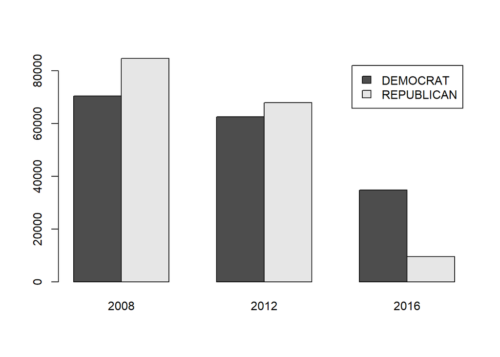

```r
legendPlot=levels(as.factor(unique(governorDR$party)))
bartable = table(governorDR$party,governorDR$election_year)  ## get the cross tab
barplot(bartable, beside = TRUE,legend=legendPlot)  ## plot
```

Una gráfica alternativa:

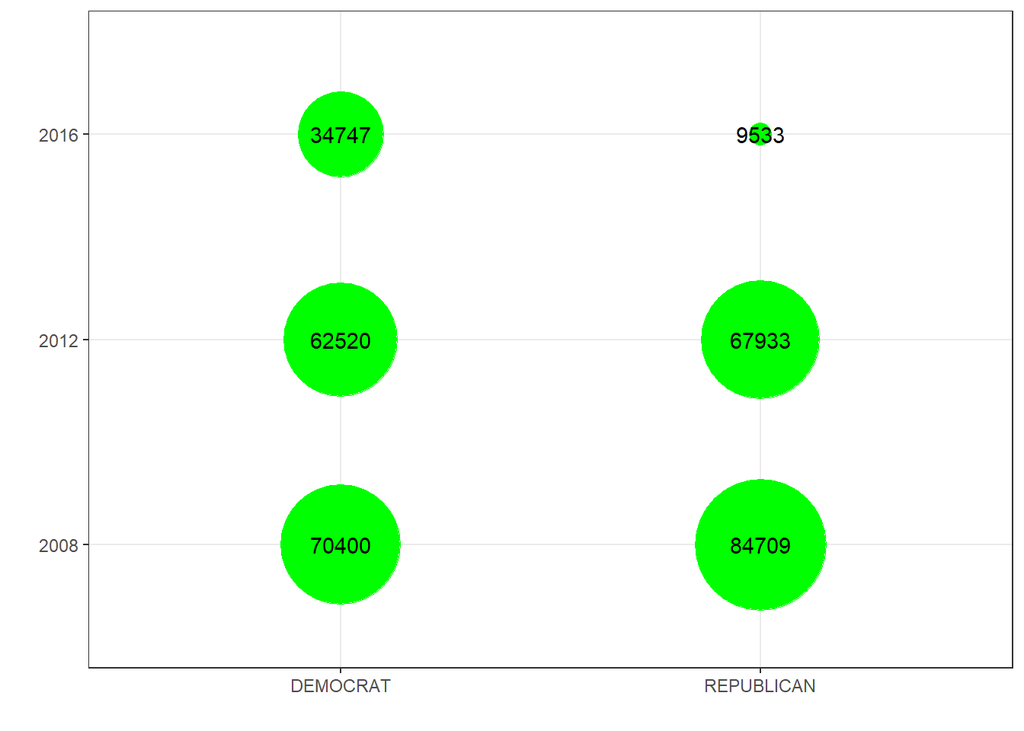

```r
library(ggplot2)

#turn table into a data frame:
governorDRTb=as.data.frame(table(governorDR$party,governorDR$election_year))
names(governorDRTb)=c('party','election_year','f')



#Plot the Data
g <- ggplot(governorDRTb, aes(party, election_year)) + geom_point(aes(size = f), colour = "green") + theme_bw() + xlab("") + ylab("") +theme(legend.position="none")
g + scale_size_continuous(range=c(5,30)) + geom_text(aes(label = f))
```